# ASK-PrEP: Cost-Effectiveness Analysis of a Stepped-Care PrEP Navigation Intervention for Sexual and Gender Minority Individuals with Substance Use Disorders

CHERISH Weill Cornell Biostatistics Internship Project

**Biostatistician:** Jordyn Begay and Adanya Bailey

**Principal Investigator:** Sean M. Murphy

*July 21, 2026*

# Background Info

**Background:** Pre-exposure prophylaxis (PrEP) is a highly effective strategy for preventing HIV infection among individuals at high risk of acquisition. However, despite its effectiveness, PrEP initiation, adherence, and persistence remain suboptimal, particularly among transgender women (TW) and men who have sex with men (MSM) who use substances. Substance use has been associated with reduced engagement across the PrEP care continuum, poorer health outcomes, and increased healthcare utilization, highlighting the need for interventions that improve PrEP uptake and sustained use in these populations.

This study evaluated the effectiveness and cost-effectiveness of the Assistance Services Knowledge–PrEP (ASK-PrEP) intervention, a PrEP navigation program incorporating Short Message Service (SMS) support within a stepped-care randomized controlled trial. Participants who did not respond to the initial ASK-PrEP intervention were re-randomized to receive either ASK-PrEP plus contingency management (CM) or CM alone. The objective was to identify the most effective and cost-effective strategy for improving engagement across the PrEP care continuum, including initiation, adherence, and persistence.

# Aims

1. Describe the baseline characteristics of the overall study cohort and compare participant characteristics by initial randomization assignment (ASK-PrEP vs. Standard of Care [SOC])
2. Evaluate the association between initial randomization assignment (ASK-PrEP vs. SOC) and PrEP initiation at 3 months, as well as healthcare costs using logistic regression and two-part cost models.
3. Evaluate the association between second-stage treatment assignment (ASK-PrEP + CM vs. CM alone) and PrEP adherence at 6, 9, and 12 months, as well as healthcare costs using logistic regression and two-part cost models.

# 1. Descriptive Statistics

## Table 1a. ASK PrEP vs. SOC

**Table 1a** presents descriptive statistics summarizing the baseline demographic, socioeconomic, and clinical characteristics of the overall study cohort. Participant characteristics are reported for the overall cohort (N = 152) and separately by initial randomization assignment (ASK-PrEP vs. Standard of Care [SOC]) to assess baseline comparability between treatment groups.

| **Characteristic** | **Overall** N = 152<sup>1</sup> | **ASK PrEP** N = 113<sup>1</sup> | **SOC** N = 39<sup>1</sup> |
| --- | --- | --- | --- |
| Gender |  |  |  |
| Male (Cisgender) | 119 (78%) | 88 (78%) | 31 (79%) |
| Prefer not to answer | 2 (1.3%) | 2 (1.8%) | 0 (0%) |
| Transgender Man/Transmasculine | 5 (3.3%) | 3 (2.7%) | 2 (5.1%) |
| Transgender Woman/Transfeminine | 26 (17%) | 20 (18%) | 6 (15%) |
| Sex Assigned at Birth |  |  |  |
| Female | 4 (2.6%) | 2 (1.8%) | 2 (5.1%) |
| Male | 146 (96%) | 110 (97%) | 36 (92%) |
| Prefer not to answer | 2 (1.3%) | 1 (0.9%) | 1 (2.6%) |
| Sexual Identity |  |  |  |
| Bisexual | 47 (31%) | 35 (31%) | 12 (31%) |
| Gay | 63 (41%) | 48 (42%) | 15 (38%) |
| Heterosexual/Straight | 15 (9.9%) | 8 (7.1%) | 7 (18%) |
| Other | 25 (16%) | 20 (18%) | 5 (13%) |
| Prefer not to Answer | 2 (1.3%) | 2 (1.8%) | 0 (0%) |
| Age |  |  |  |
| Mean (SD) | 44 (12) | 44 (12) | 45 (11) |
| Median (Q1, Q3) | 44 (34, 53) | 44 (33, 53) | 44 (37, 53) |
| Min, Max | 21, 73 | 21, 73 | 23, 65 |
| Living Situation |  |  |  |
| Stable Housing | 82 (54%) | 63 (56%) | 19 (49%) |
| Unhoused (Shelter/Transitional Housing) | 19 (13%) | 16 (14%) | 3 (7.7%) |
| Unhoused (Street Setting) | 15 (9.9%) | 12 (11%) | 3 (7.7%) |
| Unhoused (Unspecified) | 6 (3.9%) | 2 (1.8%) | 4 (10%) |
| Unstable Housing (hotel, room rental, couchsurfing, etc.,) | 30 (20%) | 20 (18%) | 10 (26%) |
| Education |  |  |  |
| Graduate Education (Some Graduate School/Graduate Degree) | 7 (4.6%) | 7 (6.2%) | 0 (0%) |
| High School/GED | 47 (31%) | 34 (30%) | 13 (33%) |
| Less than High School | 20 (13%) | 18 (16%) | 2 (5.1%) |
| Postsecondary Degree | 32 (21%) | 22 (19%) | 10 (26%) |
| Prefer not to answer | 1 (0.7%) | 1 (0.9%) | 0 (0%) |
| Some College/Technical Training | 45 (30%) | 31 (27%) | 14 (36%) |
| Race/Ethnicity |  |  |  |
| African American/Black | 46 (30%) | 35 (31%) | 11 (28%) |
| Asian | 7 (4.6%) | 5 (4.4%) | 2 (5.1%) |
| Caucasian/White | 32 (21%) | 22 (19%) | 10 (26%) |
| Hispanic/Latinx | 34 (22%) | 26 (23%) | 8 (21%) |
| Multiracial/Multiethnic | 23 (15%) | 18 (16%) | 5 (13%) |
| Native American/Alaskan Native | 5 (3.3%) | 3 (2.7%) | 2 (5.1%) |
| Native Hawaiian/Pacific Islander | 1 (0.7%) | 0 (0%) | 1 (2.6%) |
| Other | 3 (2.0%) | 3 (2.7%) | 0 (0%) |
| Prefer not to answer | 1 (0.7%) | 1 (0.9%) | 0 (0%) |
| Lifetime Injection Drug Use | 85 (56%) | 61 (54%) | 24 (62%) |
| Lifetime Needle Sharing | 32 (38%) | 22 (37%) | 10 (42%) |
| Insurance |  |  |  |
| Covered California (CA Healthcare Exchange) | 12 (7.9%) | 9 (8.0%) | 3 (7.7%) |
| Dual Eligible (Medi-Cal + Medicare) | 13 (8.6%) | 9 (8.0%) | 4 (10%) |
| Employer Provided Health Plan | 10 (6.6%) | 9 (8.0%) | 1 (2.6%) |
| Indian Health Service | 2 (1.3%) | 0 (0%) | 2 (5.1%) |
| Medi-Cal (Medicaid) | 88 (58%) | 69 (61%) | 19 (49%) |
| Medicare | 8 (5.3%) | 4 (3.5%) | 4 (10%) |
| No Coverage | 14 (9.2%) | 9 (8.0%) | 5 (13%) |
| Veterans Administration | 5 (3.3%) | 4 (3.5%) | 1 (2.6%) |
| History of STI | 82 (57%) | 59 (56%) | 23 (61%) |
| Ever Prescribed PrEP | 76 (50%) | 56 (50%) | 20 (51%) |
| Work Status |  |  |  |
| Employed | 52 (34%) | 40 (36%) | 12 (31%) |
| Retired | 6 (4.0%) | 2 (1.8%) | 4 (10%) |
| Student/Training | 8 (5.3%) | 7 (6.3%) | 1 (2.6%) |
| Unemployed | 85 (56%) | 63 (56%) | 22 (56%) |
| Out-of-Pocket Healthcare Costs |  |  |  |
| Mean (SD) | 34 (134) | 31 (143) | 45 (105) |
| Median (Q1, Q3) | 0 (0, 0) | 0 (0, 0) | 0 (0, 20) |
| Min, Max | 0, 1,200 | 0, 1,200 | 0, 500 |
| Income |  |  |  |
| $12,500 - $20,000 | 23 (15%) | 15 (13%) | 8 (21%) |
| $20,001 - $30,000 | 10 (6.7%) | 8 (7.1%) | 2 (5.3%) |
| $30,001 - $40,000 | 3 (2.0%) | 3 (2.7%) | 0 (0%) |
| $40,001 - $50,000 | 8 (5.3%) | 7 (6.3%) | 1 (2.6%) |
| $50,001 - $100,000 | 10 (6.7%) | 7 (6.3%) | 3 (7.9%) |
| Less than $12,500 | 94 (63%) | 70 (63%) | 24 (63%) |
| More than $100,000 | 2 (1.3%) | 2 (1.8%) | 0 (0%) |

<sup>1</sup> n (%)

## Table 1b. ASK PrEP + CM vs. CM

**Table 1b** presents descriptive statistics for the re-randomized cohort amongst ASK-PREP treatment nonresponders from randomization 1 (N = 57), summarized overall and by second-stage treatment assignment: ASK-PrEP + Contingency Management (CM; n = 29) versus CM alone (n = 28). Baseline demographic, socioeconomic, and clinical characteristics are reported using counts and percentages for categorical variables and means, standard deviations, medians, interquartile ranges, and ranges for continuous variables.

| **Characteristic** | **Overall** N = 57<sup>1</sup> | **ASK PrEP + CM** N = 29<sup>1</sup> | **CM** N = 28<sup>1</sup> |
| --- | --- | --- | --- |
| Gender |  |  |  |
| Male (Cisgender) | 46 (81%) | 25 (86%) | 21 (75%) |
| Prefer not to answer | 1 (1.8%) | 1 (3.4%) | 0 (0%) |
| Transgender Man/Transmasculine | 2 (3.5%) | 1 (3.4%) | 1 (3.6%) |
| Transgender Woman/Transfeminine | 8 (14%) | 2 (6.9%) | 6 (21%) |
| Sex Assigned at Birth |  |  |  |
| Female | 2 (3.5%) | 1 (3.4%) | 1 (3.6%) |
| Male | 54 (95%) | 27 (93%) | 27 (96%) |
| Prefer not to answer | 1 (1.8%) | 1 (3.4%) | 0 (0%) |
| Sexual Identity |  |  |  |
| Bisexual | 18 (32%) | 11 (38%) | 7 (25%) |
| Gay | 21 (37%) | 8 (28%) | 13 (46%) |
| Heterosexual/Straight | 6 (11%) | 2 (6.9%) | 4 (14%) |
| Other | 11 (19%) | 8 (28%) | 3 (11%) |
| Prefer not to Answer | 1 (1.8%) | 0 (0%) | 1 (3.6%) |
| Age |  |  |  |
| Mean (SD) | 47 (11) | 46 (10) | 47 (12) |
| Median (Q1, Q3) | 47 (40, 54) | 47 (41, 53) | 48 (37, 55) |
| Min, Max | 25, 73 | 25, 62 | 26, 73 |
| Living Situation |  |  |  |
| Stable Housing | 27 (47%) | 16 (55%) | 11 (39%) |
| Unhoused (Shelter/Transitional Housing) | 10 (18%) | 5 (17%) | 5 (18%) |
| Unhoused (Street Setting) | 8 (14%) | 3 (10%) | 5 (18%) |
| Unhoused (Unspecified) | 2 (3.5%) | 0 (0%) | 2 (7.1%) |
| Unstable Housing (hotel, room rental, couchsurfing, etc.,) | 10 (18%) | 5 (17%) | 5 (18%) |
| Education |  |  |  |
| High School/GED | 19 (33%) | 8 (28%) | 11 (39%) |
| Less than High School | 9 (16%) | 4 (14%) | 5 (18%) |
| Postsecondary Degree | 10 (18%) | 5 (17%) | 5 (18%) |
| Prefer not to answer | 1 (1.8%) | 0 (0%) | 1 (3.6%) |
| Some College/Technical Training | 18 (32%) | 12 (41%) | 6 (21%) |
| Race/Ethnicity |  |  |  |
| African American/Black | 20 (35%) | 11 (38%) | 9 (32%) |
| Caucasian/White | 7 (12%) | 4 (14%) | 3 (11%) |
| Hispanic/Latinx | 14 (25%) | 5 (17%) | 9 (32%) |
| Multiracial/Multiethnic | 11 (19%) | 6 (21%) | 5 (18%) |
| Native American/Alaskan Native | 3 (5.3%) | 2 (6.9%) | 1 (3.6%) |
| Other | 2 (3.5%) | 1 (3.4%) | 1 (3.6%) |
| Lifetime Injection Drug Use | 34 (61%) | 20 (69%) | 14 (52%) |
| Lifetime Needle Sharing | 14 (41%) | 9 (45%) | 5 (36%) |
| Insurance |  |  |  |
| Covered California (CA Healthcare Exchange) | 6 (11%) | 1 (3.4%) | 5 (18%) |
| Dual Eligible (Medi-Cal + Medicare) | 7 (12%) | 5 (17%) | 2 (7.1%) |
| Employer Provided Health Plan | 2 (3.5%) | 2 (6.9%) | 0 (0%) |
| Medi-Cal (Medicaid) | 36 (63%) | 17 (59%) | 19 (68%) |
| Medicare | 3 (5.3%) | 2 (6.9%) | 1 (3.6%) |
| No Coverage | 2 (3.5%) | 1 (3.4%) | 1 (3.6%) |
| Veterans Administration | 1 (1.8%) | 1 (3.4%) | 0 (0%) |
| History of STI | 26 (48%) | 13 (48%) | 13 (48%) |
| Ever Prescribed PrEP | 25 (44%) | 13 (45%) | 12 (43%) |
| Work Status |  |  |  |
| Employed | 21 (38%) | 11 (38%) | 10 (37%) |
| Retired | 1 (1.8%) | 1 (3.4%) | 0 (0%) |
| Student/Training | 2 (3.6%) | 1 (3.4%) | 1 (3.7%) |
| Unemployed | 32 (57%) | 16 (55%) | 16 (59%) |
| Out-of-Pocket Healthcare Costs |  |  |  |
| Mean (SD) | 24 (162) | 46 (226) | 2 (6) |
| Median (Q1, Q3) | 0 (0, 0) | 0 (0, 0) | 0 (0, 0) |
| Min, Max | 0, 1,200 | 0, 1,200 | 0, 25 |
| Income |  |  |  |
| $12,500 - $20,000 | 8 (14%) | 5 (17%) | 3 (11%) |
| $20,001 - $30,000 | 1 (1.8%) | 1 (3.4%) | 0 (0%) |
| $40,001 - $50,000 | 3 (5.4%) | 2 (6.9%) | 1 (3.7%) |
| $50,001 - $100,000 | 1 (1.8%) | 1 (3.4%) | 0 (0%) |
| Less than $12,500 | 42 (75%) | 19 (66%) | 23 (85%) |
| More than $100,000 | 1 (1.8%) | 1 (3.4%) | 0 (0%) |

<sup>1</sup> n (%)

# 2. Treatment Initiation and Cost Outcomes of ASK PrEP vs. SOC

## Bivariate Hypothesis Testing

Bivariate hypothesis tests were performed to compare treatment initiation success and healthcare costs between the two intervention groups prior to adjusted regression analyses. This table presents the unadjusted comparison of PrEP initiation at 3 months and total healthcare costs between participants randomized to the ASK-PrEP intervention and those receiving SOC.

| **Characteristic** | **Overall** N = 152<sup>1</sup> | **ASK PrEP** N = 113<sup>1</sup> | **SOC** N = 39<sup>1</sup> | **p-value**<sup>2</sup> |
| --- | --- | --- | --- | --- |
| PrEP Treatment Initiation Success | 48 (47%) | 42 (56%) | 6 (22%) | 0.003 |
| Unknown | 50 | 38 | 12 |  |
| Total Cost at 3 Months |  |  |  | 0.2 |
| Mean (SD) | 3,105 (11,722) | 2,609 (11,215) | 4,345 (13,010) |  |
| Median (Q1, Q3) | 0 (0, 760) | 0 (0, 0) | 0 (0, 815) |  |
| Min, Max | 0, 78,154 | 0, 78,154 | 0, 68,150 |  |
| Unknown | 40 | 33 | 7 |  |

<sup>1</sup> n (%)  
<sup>2</sup> Pearson’s Chi-squared test; Wilcoxon rank sum test

**Interpretation:** 56% of participants in the ASK-PREP arm successfully initiated PrEP by the 3-month visit, whereas only 22% of participants in the standard of care arm had (p=0.003). Healthcare costs did not significantly differ.

## Statistical Models

### Treatment Initiation: Logistic Regression

A multivariable logistic regression model was used to evaluate the association between initial randomization assignment (ASK-PrEP vs. SOC) and PrEP initiation at 3 months, when controlling for covariates. The model adjusted for insurance status, income, living situation, lifetime injection drug use, and race/ethnicity. Adjusted odds ratios (ORs), 95% confidence intervals (CIs), and p-values are reported.

| **Characteristic** | **OR** | **95% CI** | **p-value** |
| --- | --- | --- | --- |
| Randomization Assignment 1 |  |  |  |
| SOC | — | — |  |
| ASK PrEP | 4.79 | 1.57, 17.0 | 0.009 |
| Insurance |  |  |  |
| Commercial | — | — |  |
| Public | 1.22 | 0.27, 5.74 | 0.8 |
| Other/Uninsured | 2.31 | 0.32, 19.0 | 0.4 |
| Income |  |  |  |
| <$12,500 | — | — |  |
| $12,500-$30,000 | 0.99 | 0.28, 3.52 | >0.9 |
| >$30,000 | 1.71 | 0.39, 7.83 | 0.5 |
| Living situation |  |  |  |
| Stable housing | — | — |  |
| Unhoused | 0.80 | 0.22, 2.78 | 0.7 |
| Unstable housing | 1.11 | 0.31, 4.10 | 0.9 |
| Lifetime injection drug use | 0.22 | 0.07, 0.65 | 0.008 |
| Race/ethnicity |  |  |  |
| Caucasian/White | — | — |  |
| African American/Black | 0.33 | 0.07, 1.46 | 0.2 |
| Hispanic/Latinx | 1.35 | 0.32, 5.85 | 0.7 |
| Other | 1.05 | 0.25, 4.40 | >0.9 |

Abbreviations: CI = Confidence Interval, OR = Odds Ratio

### Cost : Two-Part Model

A two-part model was used to evaluate the association between initial randomization assignment (ASK-PrEP vs. SOC) and total healthcare costs at 3 months. The first part of the model used logistic regression to estimate the probability of incurring any healthcare costs, while the second part used a Gamma regression with a log link to model the amount of healthcare costs among participants with non-zero costs. Adjusted marginal effects were estimated to quantify the difference in healthcare costs between treatment groups.

| Variable | Marginal difference in cost | P-value |
| --- | --- | --- |
| ASK PrEP - SOC | -1256.73 (-6513.53, 4000.07) | 0.6394 |

# 3. Treatment Initiation and Cost Outcome of ASK PrEP + CM vs. CM (6, 9 , and 12 Months)

## Bivariate Hypothesis Testing

This table presents the unadjusted comparison of PrEP maintenance at 6, 9, and 12 months and cumulative healthcare costs among participants re-randomized to ASK-PrEP + Contingency Management (CM) or CM alone. These results summarize the unadjusted differences in PrEP maintenance and healthcare costs between the two second-stage treatment groups prior to adjusted logistic regression and two-part cost model analyses.

| **Characteristic** | **ASK PrEP + CM** N = 29<sup>1</sup> | **CM** N = 28<sup>1</sup> | **p-value**<sup>2</sup> |
| --- | --- | --- | --- |
| 6 Month: PrEP Maintenance Success | 6 (38%) | 3 (17%) | 0.2 |
| Unknown | 13 | 10 |  |
| 9 Month: PrEP Maintenance Success | 2 (13%) | 3 (21%) | 0.6 |
| Unknown | 13 | 14 |  |
| 12 Month: PrEP Maintenance Success | 2 (15%) | 1 (7.7%) | >0.9 |
| Unknown | 16 | 15 |  |
| Total Cost at 6 Months |  |  | 0.2 |
| Mean (SD) | 303 (982) | 4,275 (10,986) |  |
| Median (Q1, Q3) | 0 (0, 0) | 0 (0, 1,520) |  |
| Min, Max | 0, 3,868 | 0, 41,226 |  |
| Unknown | 8 | 5 |  |
| Total Cost at 9 Months |  |  | 0.6 |
| Mean (SD) | 1,666 (4,152) | 23,818 (75,606) |  |
| Median (Q1, Q3) | 0 (0, 760) | 0 (0, 1,520) |  |
| Min, Max | 0, 15,798 | 0, 311,662 |  |
| Unknown | 12 | 11 |  |
| Total Cost at 12 Months |  |  | 0.3 |
| Mean (SD) | 2,607 (5,718) | 36,816 (100,638) |  |
| Median (Q1, Q3) | 0 (0, 1,050) | 580 (0, 3,040) |  |
| Min, Max | 0, 19,882 | 0, 364,450 |  |
| Unknown | 16 | 15 |  |

<sup>1</sup> n (%)  
<sup>2</sup> Fisher’s exact test; Wilcoxon rank sum test

**Interpretation** There were no statistically significant differences in PrEP maintenance between participants randomized to ASK-PrEP + CM and those receiving CM alone at 6, 9, or 12 months (p = 0.2, 0.6, and >0.9, respectively). Similarly, cumulative healthcare costs did not differ significantly between treatment groups at any follow-up time point, suggesting that adding ASK-PrEP to CM was not associated with increased healthcare costs.

## Statistical Models

### Treatment Initiation: Logistic Regression

| **Characteristic** | **6 months** **OR** | **6 months** **95% CI** | **6 months** **p-value** | **9 months** **OR** | **9 months** **95% CI** | **9 months** **p-value** | **12 months** **OR** | **12 months** **95% CI** | **12 months** **p-value** |
| --- | --- | --- | --- | --- | --- | --- | --- | --- | --- |
| Randomization Assignment 2 |  |  |  |  |  |  |  |  |  |
| CM | — | — |  | — | — |  | — | — |  |
| ASK PrEP + CM | 1.90 | 0.16, 24.4 | 0.6 | 0.34 | 0.03, 2.82 | 0.3 | 2.36 | 0.19, 56.5 | 0.5 |
| Insurance |  |  |  |  |  |  |  |  |  |
| Commercial | — | — |  |  |  |  |  |  |  |
| Public | 12.3 | 0.08, 20,906 | 0.4 |  |  |  |  |  |  |
| Other/Uninsured | 15.9 | 0.04, 93,214 | 0.4 |  |  |  |  |  |  |
| Income |  |  |  |  |  |  |  |  |  |
| <$12,500 | — | — |  | — | — |  |  |  |  |
| $12,500-$30,000 | 29.7 | 1.96, 2,145 | 0.041 | 2.13 | 0.21, 19.9 | 0.5 |  |  |  |
| >$30,000 | 104 | 0.37, 506,491 | 0.2 | 0.00 |  | >0.9 |  |  |  |
| Living situation |  |  |  |  |  |  |  |  |  |
| Stable housing | — | — |  | — | — |  |  |  |  |
| Unhoused | 4.17 | 0.29, 141 | 0.3 | 0.56 | 0.02, 6.70 | 0.7 |  |  |  |
| Unstable housing | 0.03 | 0.00, 2.72 | 0.2 | 0.70 | 0.02, 12.0 | 0.8 |  |  |  |
| Lifetime injection drug use | 0.05 | 0.00, 1.70 | 0.14 | 1.29 | 0.12, 19.9 | 0.8 | 0.42 | 0.02, 5.16 | 0.5 |
| Race/ethnicity |  |  |  |  |  |  |  |  |  |
| Caucasian/White | — | — |  |  |  |  |  |  |  |
| African American/Black | 0.03 | 0.00, 2.19 | 0.12 |  |  |  |  |  |  |
| Hispanic/Latinx | 0.43 | 0.01, 18.8 | 0.6 |  |  |  |  |  |  |
| Other | 0.03 | 0.00, 2.66 | 0.14 |  |  |  |  |  |  |

Abbreviations: CI = Confidence Interval, OR = Odds Ratio

### Cost : Two-Part Model

A longitudinal two-part model was used to compare total healthcare costs between participants assigned to ASK-PrEP + Contingency Management (CM) and those assigned to CM alone across the 6-, 9-, and 12-month follow-up periods. The first part modeled the probability of incurring any healthcare costs using logistic regression, while the second part modeled the amount of cost among participants with nonzero costs using a Gamma regression with a log link. Because of the small sample size, the model adjusted only for lifetime injection drug use history and included treatment-by-timepoint interaction terms to estimate adjusted marginal differences in cost at each follow-up time point.

| Variable | Marginal difference in cost | P-value |
| --- | --- | --- |
| ASK PrEP + CM - CM alone | -5598.62 (-14220.28, 3023.04) | 0.2031 |
| ASK PrEP + CM - CM alone | -1972.54 (-5165.23, 1220.15) | 0.2259 |
| ASK PrEP + CM - CM alone | -12850.66 (-32285.36, 6584.05) | 0.1950 |

# Figures:

[figure not shown]

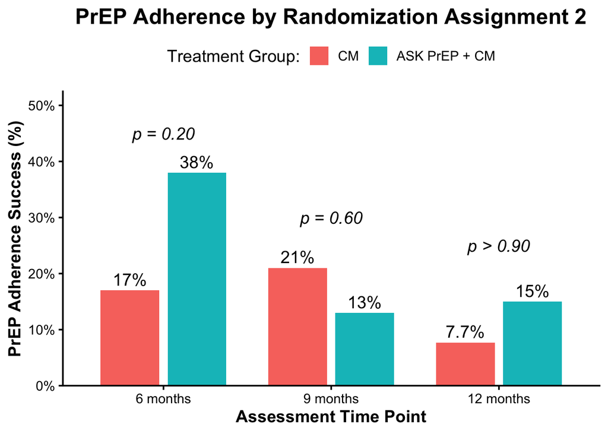

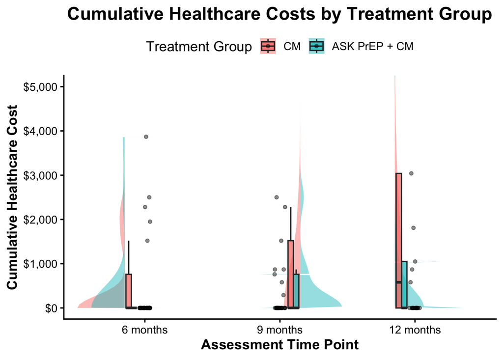

# Conclusions

1. Participants randomized to the ASK-PrEP intervention had significantly greater odds of successful PrEP initiation at 3 months compared with those receiving Standard of Care (SOC), after adjusting for baseline demographic and clinical characteristics.
2. Among participants who were re-randomized at 6 months, ASK-PrEP + Contingency Management (CM) did not significantly improve PrEP maintenance at 6, 9, or 12 months compared with CM alone after adjustment for relevant baseline covariates.
3. Healthcare costs did not differ significantly between treatment groups in either the initial treatment comparison (ASK-PrEP vs. SOC) or the second-stage treatment comparison (ASK-PrEP + CM vs. CM alone), suggesting that the interventions were not associated with increased healthcare costs.

Overall, the findings suggest that ASK-PrEP may improve short-term PrEP initiation without increasing healthcare costs. However, among participants requiring a second-stage intervention, ASK-PrEP + CM did not significantly improve long-term PrEP maintenance compared with CM alone, indicating that additional strategies may be needed to support sustained PrEP use.

**Note**: This study was terminated as a result of recent federal funding cuts affecting research focused on gender and sexual minority populations. The abrupt discontinuation of funding led to the dissolution of the study’s analysis team before the collected data could be fully analyzed. The work completed this summer by this student research group is helping ensure that valuable insights are still generated from the available data, enabling actionable findings that otherwise may not have been realized.

Division of Biostatistics

Department of Population Health Sciences

Jordyn Begay and Adanya Bailey